# BC LTC Analysis

KT Hobbs

02/08/2020

## Import and prepare the data

```r
library(skimr)

# Import the data
df <- read.csv("../data/bc-ltc-FINAL.csv", na.strings="", header=TRUE)
colnames(df)
```

```r
# drop unneccessary columns
# incidents by category are removed, incidents per 100 beds is kept
rmv <- c("X", "Unnamed..0", "Unnamed..0.1", "facility_name", "HCC_CODE", "HLTH_AUTH", "STREET_ADDRESS", "CITY", "POSTAL", "PHONE", "FACILITY_NAME",
         "OPEN_DATE",  "provider", "BUSINESS_PHONE",
         "COUNCIL", "ACCRED_STATUS", "INCIDENT_OUTBREAK", "INCIDENT_ABUSE", "INCIDENT_FALL",
         "INCIDENT_POISON", "INCIDENT_MEDICATION", "INCIDENT_WANDERING", "INCIDENT_INJURY", "INCIDENT_AGGRESSION",
        'latitude', 'longitude', 'point', 'LATITUDE', 'LONGITUDE', 'geometry',
        'Number.of.dead' # removing number of dead because we are using outbreak as a response
  )

df2 <- df[, -which(names(df) %in% rmv)]

skim(df2)
```

Data summary

| Name | df2 |
| --- | --- |
| Number of rows | 297 |
| Number of columns | 55 |
| _______________________ |  |
| Column type frequency: |  |
| factor | 34 |
| numeric | 21 |
| ________________________ |  |
| Group variables | None |

**Variable type: factor**

| skim_variable | n_missing | complete_rate | ordered | n_unique | top_counts |
| --- | --- | --- | --- | --- | --- |
| COMPLAINTS | 14 | 0.95 | FALSE | 18 | 0: 139, 1: 64, 2: 22, 3: 16 |
| SUB_COMPLAINTS | 14 | 0.95 | FALSE | 10 | 0: 201, 1: 52, 2: 8, 3: 5 |
| INCIDENT_OUTBREAK_100 | 25 | 0.92 | FALSE | 38 | 0: 149, 1: 10, 2: 9, 0.9: 8 |
| INCIDENT_ABUSE_100 | 25 | 0.92 | FALSE | 51 | 0: 162, 0.8: 6, 1: 6, 0.9: 5 |
| INCIDENT_FALL_100 | 25 | 0.92 | FALSE | 143 | 0: 20, 2.8: 6, 10.: 5, 10.: 4 |
| INCIDENT_POISON_100 | 25 | 0.92 | FALSE | 11 | 0: 258, sup: 4, 0.4: 2, 0.6: 1 |
| INCIDENT_MEDICATION_100 | 25 | 0.92 | FALSE | 14 | 0: 239, 1: 6, 0.8: 5, sup: 4 |
| INCIDENT_WANDERING_100 | 25 | 0.92 | FALSE | 62 | 0: 136, 1.3: 9, 3: 7, 1.1: 6 |
| INCIDENT_INJURY_100 | 25 | 0.92 | FALSE | 61 | 0: 113, 1.3: 9, 2: 8, 0.8: 7 |
| INCIDENT_AGGRESSION_100 | 25 | 0.92 | FALSE | 54 | 0: 160, 1: 6, 1.3: 6, 0.7: 5 |
| AGE | 3 | 0.99 | FALSE | 21 | 84: 43, 85: 43, 87: 35, 83: 34 |
| FEMALE | 3 | 0.99 | FALSE | 195 | 0.6: 7, 0.5: 4, 0.6: 4, 0.6: 4 |
| AGE_85_PLUS | 3 | 0.99 | FALSE | 203 | 0.5: 5, 0.5: 4, 0.5: 4, 0.5: 4 |
| AGE_UNDER_65 | 3 | 0.99 | FALSE | 110 | 0: 16, 0.0: 10, 0.0: 8, 0.0: 8 |
| STAY_LENGTH | 13 | 0.96 | FALSE | 245 | sup: 4, 607: 3, 638: 3, 862: 3 |
| DEPRESSION | 3 | 0.99 | FALSE | 204 | 0.2: 5, 0.2: 5, 0.1: 4, sup: 4 |
| ADL_DEPENDENT | 3 | 0.99 | FALSE | 201 | 0.3: 6, 0: 5, 0.3: 5, 0.1: 4 |
| CPS_SEVERE | 3 | 0.99 | FALSE | 197 | 0.2: 5, 0.2: 5, 0.2: 4, sup: 4 |
| DEMENTIA | 3 | 0.99 | FALSE | 215 | 0.6: 4, 0.6: 4, 0.7: 4, sup: 4 |
| ABS_PHYS_ABUSIVE | 3 | 0.99 | FALSE | 143 | 0: 7, 0.0: 7, 0.0: 7, 0.0: 6 |
| ISE | 4 | 0.99 | FALSE | 38 | 2.6: 24, 2.9: 24, 2.8: 20, 2.2: 18 |
| ISE_LOW | 3 | 0.99 | FALSE | 232 | 0.4: 4, sup: 4, 0.2: 3, 0.3: 3 |
| CMI | 4 | 0.99 | FALSE | 28 | 0.5: 39, 0.5: 37, 0.5: 37, 0.5: 34 |
| THERAPY_PT | 3 | 0.99 | FALSE | 159 | 0: 51, 0.0: 8, 0.0: 8, 0.0: 6 |
| THERAPY_RT | 3 | 0.99 | FALSE | 195 | 0: 47, 0.0: 6, 0.0: 5, 0.0: 4 |
| THERAPY_OT | 3 | 0.99 | FALSE | 107 | 0: 107, 0.0: 10, 0.0: 10, 0.0: 8 |
| MEDS_DEPRESSION | 3 | 0.99 | FALSE | 202 | 0.5: 5, 0.4: 4, sup: 4, 0.3: 3 |
| MEDS_ANTIPSYCHOTICS | 3 | 0.99 | FALSE | 204 | 0.2: 5, 0.2: 5, 0.2: 4, sup: 4 |
| RESTRAINTS | 3 | 0.99 | FALSE | 150 | 0: 25, 0.0: 6, 0.0: 5, 0.0: 5 |
| outbreak_status | 0 | 1.00 | FALSE | 2 | no: 282, yes: 15 |
| residents_council | 0 | 1.00 | FALSE | 2 | yes: 265, no: 32 |
| family_council | 0 | 1.00 | FALSE | 2 | yes: 251, no: 46 |
| accreditation | 0 | 1.00 | FALSE | 3 | yes: 201, unk: 62, no: 34 |
| home_type | 0 | 1.00 | FALSE | 3 | hea: 112, for: 102, non: 83 |

**Variable type: numeric**

| skim_variable | n_missing | complete_rate | mean | sd | p0 | p25 | p50 | p75 | p100 | hist |
| --- | --- | --- | --- | --- | --- | --- | --- | --- | --- | --- |
| BEDS_PRIVATE | 0 | 1.00 | 4.79 | 13.19 | 0 | 0 | 0 | 2 | 115 | ▇▁▁▁▁ |
| BEDS_PUBLIC | 0 | 1.00 | 91.87 | 55.96 | 5 | 53 | 85 | 117 | 300 | ▆▇▂▁▁ |
| BEDS_TOTAL | 0 | 1.00 | 96.66 | 56.71 | 5 | 59 | 90 | 124 | 300 | ▅▇▃▂▁ |
| ROOMS_PRIVATE | 0 | 1.00 | 70.19 | 52.41 | 0 | 29 | 66 | 102 | 284 | ▇▇▂▁▁ |
| ROOMS_SEMI | 0 | 1.00 | 6.28 | 11.46 | 0 | 0 | 2 | 8 | 90 | ▇▁▁▁▁ |
| ROOMS_MULTI | 0 | 1.00 | 3.25 | 10.87 | 0 | 0 | 0 | 0 | 116 | ▇▁▁▁▁ |
| INSPECTIONS | 3 | 0.99 | 2.60 | 2.78 | 0 | 1 | 2 | 3 | 19 | ▇▂▁▁▁ |
| INFRACTIONS | 3 | 0.99 | 3.75 | 4.34 | 0 | 1 | 3 | 5 | 34 | ▇▂▁▁▁ |
| INFRACTIONS_LICENSING | 3 | 0.99 | 0.16 | 0.58 | 0 | 0 | 0 | 0 | 6 | ▇▁▁▁▁ |
| INFRACTIONS_FACILITY | 3 | 0.99 | 0.71 | 1.14 | 0 | 0 | 0 | 1 | 9 | ▇▁▁▁▁ |
| INFRACTIONS_STAFFING | 3 | 0.99 | 0.48 | 0.92 | 0 | 0 | 0 | 1 | 5 | ▇▁▁▁▁ |
| INFRACTIONS_POLICY | 3 | 0.99 | 0.37 | 1.02 | 0 | 0 | 0 | 0 | 12 | ▇▁▁▁▁ |
| INFRACTIONS_CARE | 3 | 0.99 | 0.80 | 1.29 | 0 | 0 | 0 | 1 | 10 | ▇▁▁▁▁ |
| INFRACTIONS_DISEASE | 3 | 0.99 | 0.20 | 0.48 | 0 | 0 | 0 | 0 | 3 | ▇▁▁▁▁ |
| INFRACTIONS_FOOD | 3 | 0.99 | 0.07 | 0.30 | 0 | 0 | 0 | 0 | 3 | ▇▁▁▁▁ |
| INFRACTIONS_MEDICATION | 3 | 0.99 | 0.13 | 0.38 | 0 | 0 | 0 | 0 | 2 | ▇▁▁▁▁ |
| INFRACTIONS_PROGRAM | 3 | 0.99 | 0.03 | 0.16 | 0 | 0 | 0 | 0 | 1 | ▇▁▁▁▁ |
| INFRACTIONS_REPORTING | 3 | 0.99 | 0.74 | 1.18 | 0 | 0 | 0 | 1 | 8 | ▇▁▁▁▁ |
| INFRACTIONS_RIGHTS | 3 | 0.99 | 0.12 | 0.51 | 0 | 0 | 0 | 0 | 6 | ▇▁▁▁▁ |
| INFRACTIONS_OTHER | 3 | 0.99 | 0.00 | 0.06 | 0 | 0 | 0 | 0 | 1 | ▇▁▁▁▁ |
| years_operating | 10 | 0.97 | 29.45 | 16.01 | 1 | 15 | 29 | 41 | 110 | ▆▇▂▁▁ |

Numerical Variables are all right-skewed. Since they all have similar distributions - is it alright to leave them as is (no transformation)?

#### Cleaning

```r
# Change time-related and ordinal categorical variables to factor
# yrs <- c('years_operating', 'AGE', 'AGE_85_PLUS', 'AGE_UNDER_65')
#
# for (i in yrs){
#   df2[,i] <- as.factor(as.character(df2[,i]))
# }

# Convert beds, rooms, and infractions to a proportion of total
# BEDS
df2$BEDS_PRIV_PROP <- df2$BEDS_PRIVATE/df2$BEDS_TOTAL
df2$BEDS_PUB_PROP <- df2$BEDS_PUBLIC/df2$BEDS_TOTAL

# ROOMS
df2$ROOMS_TOTAL <- df2$ROOMS_PRIVATE + df2$ROOMS_SEMI + df2$ROOMS_MULTI
df2$ROOMS_PRIV_PROP <- df2$ROOMS_PRIVATE/df2$ROOMS_TOTAL
df2$ROOMS_SEMI_PROP <- df2$ROOMS_SEMI/df2$ROOMS_TOTAL
df2$ROOMS_MULTI_PROP <- df2$ROOMS_MULTI/df2$ROOMS_TOTAL


# Remove redundant cols
# removing AGE because AGE_UNDER_65 and AGE_85_AND_OVER are more descriptive
# remove complaints because they include unsubstantiated complaints. Same logic for inspections (infractions are more telling).

rmv2 <- c('BEDS_PRIVATE', 'BEDS_PUBLIC',
          'ROOMS_PRIVATE', 'ROOMS_SEMI', 'ROOMS_MULTI',
          'AGE', 'COMPLAINTS', 'INSPECTIONS')

df3 <- df2[, -which(names(df2) %in% rmv2)]
```

Group data for ease later

```r
size <- c('BEDS_PRIV_PROP', 'BEDS_PUB_PROP', 'BEDS_TOTAL', 'ROOMS_PRIV_PROP', 'ROOMS_PUB_PROP', 'ROOMS_MULTI_PROP',
          'ROOMS_TOTAL')

resident_profile <- df3[,11:28]

quality <- df3[,c(2:10, 29:41)]

general<- df3[,42:48]

# colnames(df3)
```

Converting `INCIDENTS_*` and remaining resident profile predictors to numeric…

**NOTE:** ‘suppressed’ converted to NA by coercion

```r
# resident profile params
df3[,names(resident_profile)] <- lapply(df3[,names(resident_profile)],FUN = as.character)
df3[,names(resident_profile)] <- lapply(df3[,names(resident_profile)],FUN = as.numeric)
```

[output not shown]

```r
# incidents
df3[,grep('^INCIDENT.',colnames(df3))] <- lapply(df3[,grep('^INCIDENT.',colnames(df3))], FUN = as.character)
df3[,grep('^INCIDENT.',colnames(df3))] <- lapply(df3[,grep('^INCIDENT.',colnames(df3))], FUN = as.numeric)
# sub complaints
df3$SUB_COMPLAINTS <- as.numeric(df3$SUB_COMPLAINTS)

# years operating
df3$years_operating <- as.numeric(as.character(df3$years_operating))

skim(df3)
```

Data summary

| Name | df3 |
| --- | --- |
| Number of rows | 297 |
| Number of columns | 53 |
| _______________________ |  |
| Column type frequency: |  |
| factor | 5 |
| numeric | 48 |
| ________________________ |  |
| Group variables | None |

**Variable type: factor**

| skim_variable | n_missing | complete_rate | ordered | n_unique | top_counts |
| --- | --- | --- | --- | --- | --- |
| outbreak_status | 0 | 1 | FALSE | 2 | no: 282, yes: 15 |
| residents_council | 0 | 1 | FALSE | 2 | yes: 265, no: 32 |
| family_council | 0 | 1 | FALSE | 2 | yes: 251, no: 46 |
| accreditation | 0 | 1 | FALSE | 3 | yes: 201, unk: 62, no: 34 |
| home_type | 0 | 1 | FALSE | 3 | hea: 112, for: 102, non: 83 |

**Variable type: numeric**

| skim_variable | n_missing | complete_rate | mean | sd | p0 | p25 | p50 | p75 | p100 | hist |
| --- | --- | --- | --- | --- | --- | --- | --- | --- | --- | --- |
| BEDS_TOTAL | 0 | 1.00 | 96.66 | 56.71 | 5.00 | 59.00 | 90.00 | 124.00 | 300.00 | ▅▇▃▂▁ |
| SUB_COMPLAINTS | 14 | 0.95 | 1.74 | 1.75 | 1.00 | 1.00 | 1.00 | 2.00 | 10.00 | ▇▁▁▁▁ |
| INCIDENT_OUTBREAK_100 | 29 | 0.90 | 0.76 | 1.25 | 0.00 | 0.00 | 0.00 | 1.20 | 12.50 | ▇▁▁▁▁ |
| INCIDENT_ABUSE_100 | 29 | 0.90 | 0.98 | 1.77 | 0.00 | 0.00 | 0.00 | 1.40 | 13.00 | ▇▁▁▁▁ |
| INCIDENT_FALL_100 | 29 | 0.90 | 8.95 | 6.42 | 0.00 | 4.00 | 8.70 | 12.30 | 42.90 | ▇▇▁▁▁ |
| INCIDENT_POISON_100 | 29 | 0.90 | 0.05 | 0.29 | 0.00 | 0.00 | 0.00 | 0.00 | 2.60 | ▇▁▁▁▁ |
| INCIDENT_MEDICATION_100 | 29 | 0.90 | 0.12 | 0.43 | 0.00 | 0.00 | 0.00 | 0.00 | 4.50 | ▇▁▁▁▁ |
| INCIDENT_WANDERING_100 | 29 | 0.90 | 1.49 | 2.34 | 0.00 | 0.00 | 0.00 | 2.20 | 18.60 | ▇▁▁▁▁ |
| INCIDENT_INJURY_100 | 29 | 0.90 | 1.80 | 2.48 | 0.00 | 0.00 | 1.00 | 2.70 | 13.30 | ▇▂▁▁▁ |
| INCIDENT_AGGRESSION_100 | 29 | 0.90 | 1.26 | 2.41 | 0.00 | 0.00 | 0.00 | 1.70 | 15.40 | ▇▁▁▁▁ |
| FEMALE | 7 | 0.98 | 0.65 | 0.11 | 0.20 | 0.60 | 0.65 | 0.71 | 0.95 | ▁▁▇▇▁ |
| AGE_85_PLUS | 7 | 0.98 | 0.58 | 0.13 | 0.00 | 0.52 | 0.59 | 0.66 | 1.00 | ▁▁▇▇▁ |
| AGE_UNDER_65 | 7 | 0.98 | 0.05 | 0.08 | 0.00 | 0.02 | 0.04 | 0.06 | 0.94 | ▇▁▁▁▁ |
| STAY_LENGTH | 17 | 0.94 | 882.99 | 425.12 | 2.00 | 636.50 | 817.50 | 1049.25 | 3872.00 | ▆▇▁▁▁ |
| DEPRESSION | 7 | 0.98 | 0.24 | 0.10 | 0.00 | 0.17 | 0.23 | 0.29 | 0.59 | ▂▇▆▂▁ |
| ADL_DEPENDENT | 7 | 0.98 | 0.30 | 0.11 | 0.00 | 0.23 | 0.30 | 0.37 | 0.65 | ▁▅▇▃▁ |
| CPS_SEVERE | 7 | 0.98 | 0.29 | 0.11 | 0.00 | 0.22 | 0.28 | 0.35 | 0.70 | ▁▇▇▂▁ |
| DEMENTIA | 7 | 0.98 | 0.64 | 0.14 | 0.00 | 0.58 | 0.66 | 0.73 | 0.98 | ▁▁▃▇▂ |
| ABS_PHYS_ABUSIVE | 7 | 0.98 | 0.08 | 0.05 | 0.00 | 0.05 | 0.08 | 0.11 | 0.32 | ▇▇▂▁▁ |
| ISE | 8 | 0.97 | 2.76 | 0.67 | 0.90 | 2.30 | 2.70 | 3.10 | 5.30 | ▁▇▇▂▁ |
| ISE_LOW | 7 | 0.98 | 0.47 | 0.16 | 0.00 | 0.37 | 0.47 | 0.58 | 0.88 | ▁▃▇▅▁ |
| CMI | 8 | 0.97 | 0.58 | 0.04 | 0.44 | 0.56 | 0.57 | 0.59 | 0.89 | ▁▇▁▁▁ |
| THERAPY_PT | 7 | 0.98 | 0.11 | 0.14 | 0.00 | 0.01 | 0.04 | 0.16 | 0.76 | ▇▂▁▁▁ |
| THERAPY_RT | 7 | 0.98 | 0.29 | 0.29 | 0.00 | 0.01 | 0.15 | 0.57 | 0.94 | ▇▂▂▃▁ |
| THERAPY_OT | 7 | 0.98 | 0.06 | 0.12 | 0.00 | 0.00 | 0.01 | 0.06 | 0.73 | ▇▁▁▁▁ |
| MEDS_DEPRESSION | 7 | 0.98 | 0.49 | 0.12 | 0.00 | 0.42 | 0.49 | 0.56 | 0.84 | ▁▁▇▆▁ |
| MEDS_ANTIPSYCHOTICS | 7 | 0.98 | 0.25 | 0.12 | 0.00 | 0.17 | 0.24 | 0.31 | 0.81 | ▃▇▃▁▁ |
| RESTRAINTS | 7 | 0.98 | 0.07 | 0.06 | 0.00 | 0.02 | 0.06 | 0.11 | 0.34 | ▇▅▂▁▁ |
| INFRACTIONS | 3 | 0.99 | 3.75 | 4.34 | 0.00 | 1.00 | 3.00 | 5.00 | 34.00 | ▇▂▁▁▁ |
| INFRACTIONS_LICENSING | 3 | 0.99 | 0.16 | 0.58 | 0.00 | 0.00 | 0.00 | 0.00 | 6.00 | ▇▁▁▁▁ |
| INFRACTIONS_FACILITY | 3 | 0.99 | 0.71 | 1.14 | 0.00 | 0.00 | 0.00 | 1.00 | 9.00 | ▇▁▁▁▁ |
| INFRACTIONS_STAFFING | 3 | 0.99 | 0.48 | 0.92 | 0.00 | 0.00 | 0.00 | 1.00 | 5.00 | ▇▁▁▁▁ |
| INFRACTIONS_POLICY | 3 | 0.99 | 0.37 | 1.02 | 0.00 | 0.00 | 0.00 | 0.00 | 12.00 | ▇▁▁▁▁ |
| INFRACTIONS_CARE | 3 | 0.99 | 0.80 | 1.29 | 0.00 | 0.00 | 0.00 | 1.00 | 10.00 | ▇▁▁▁▁ |
| INFRACTIONS_DISEASE | 3 | 0.99 | 0.20 | 0.48 | 0.00 | 0.00 | 0.00 | 0.00 | 3.00 | ▇▁▁▁▁ |
| INFRACTIONS_FOOD | 3 | 0.99 | 0.07 | 0.30 | 0.00 | 0.00 | 0.00 | 0.00 | 3.00 | ▇▁▁▁▁ |
| INFRACTIONS_MEDICATION | 3 | 0.99 | 0.13 | 0.38 | 0.00 | 0.00 | 0.00 | 0.00 | 2.00 | ▇▁▁▁▁ |
| INFRACTIONS_PROGRAM | 3 | 0.99 | 0.03 | 0.16 | 0.00 | 0.00 | 0.00 | 0.00 | 1.00 | ▇▁▁▁▁ |
| INFRACTIONS_REPORTING | 3 | 0.99 | 0.74 | 1.18 | 0.00 | 0.00 | 0.00 | 1.00 | 8.00 | ▇▁▁▁▁ |
| INFRACTIONS_RIGHTS | 3 | 0.99 | 0.12 | 0.51 | 0.00 | 0.00 | 0.00 | 0.00 | 6.00 | ▇▁▁▁▁ |
| INFRACTIONS_OTHER | 3 | 0.99 | 0.00 | 0.06 | 0.00 | 0.00 | 0.00 | 0.00 | 1.00 | ▇▁▁▁▁ |
| years_operating | 10 | 0.97 | 29.45 | 16.01 | 1.00 | 15.00 | 29.00 | 41.00 | 110.00 | ▆▇▂▁▁ |
| BEDS_PRIV_PROP | 0 | 1.00 | 0.05 | 0.12 | 0.00 | 0.00 | 0.00 | 0.03 | 0.82 | ▇▁▁▁▁ |
| BEDS_PUB_PROP | 0 | 1.00 | 0.95 | 0.12 | 0.18 | 0.97 | 1.00 | 1.00 | 1.00 | ▁▁▁▁▇ |
| ROOMS_TOTAL | 0 | 1.00 | 79.72 | 51.27 | 0.00 | 42.00 | 74.00 | 108.00 | 292.00 | ▇▇▂▁▁ |
| ROOMS_PRIV_PROP | 5 | 0.98 | 0.84 | 0.26 | 0.00 | 0.84 | 0.97 | 1.00 | 1.00 | ▁▁▁▁▇ |
| ROOMS_SEMI_PROP | 5 | 0.98 | 0.09 | 0.15 | 0.00 | 0.00 | 0.03 | 0.12 | 0.83 | ▇▁▁▁▁ |
| ROOMS_MULTI_PROP | 5 | 0.98 | 0.07 | 0.18 | 0.00 | 0.00 | 0.00 | 0.00 | 0.81 | ▇▁▁▁▁ |

**Assessing sparsity of dataframe and handling NAs:**

```r
colSums(is.na(df3))
```

```
##              BEDS_TOTAL          SUB_COMPLAINTS   INCIDENT_OUTBREAK_100
##                       0                      14                      29
##      INCIDENT_ABUSE_100       INCIDENT_FALL_100     INCIDENT_POISON_100
##                      29                      29                      29
## INCIDENT_MEDICATION_100  INCIDENT_WANDERING_100     INCIDENT_INJURY_100
##                      29                      29                      29
## INCIDENT_AGGRESSION_100                  FEMALE             AGE_85_PLUS
##                      29                       7                       7
##            AGE_UNDER_65             STAY_LENGTH              DEPRESSION
##                       7                      17                       7
##           ADL_DEPENDENT              CPS_SEVERE                DEMENTIA
##                       7                       7                       7
##        ABS_PHYS_ABUSIVE                     ISE                 ISE_LOW
##                       7                       8                       7
##                     CMI              THERAPY_PT              THERAPY_RT
##                       8                       7                       7
##              THERAPY_OT         MEDS_DEPRESSION     MEDS_ANTIPSYCHOTICS
##                       7                       7                       7
##              RESTRAINTS             INFRACTIONS   INFRACTIONS_LICENSING
##                       7                       3                       3
##    INFRACTIONS_FACILITY    INFRACTIONS_STAFFING      INFRACTIONS_POLICY
##                       3                       3                       3
##        INFRACTIONS_CARE     INFRACTIONS_DISEASE        INFRACTIONS_FOOD
##                       3                       3                       3
##  INFRACTIONS_MEDICATION     INFRACTIONS_PROGRAM   INFRACTIONS_REPORTING
##                       3                       3                       3
##      INFRACTIONS_RIGHTS       INFRACTIONS_OTHER         outbreak_status
##                       3                       3                       0
##       residents_council          family_council           accreditation
##                       0                       0                       0
##               home_type         years_operating          BEDS_PRIV_PROP
##                       0                      10                       0
##           BEDS_PUB_PROP             ROOMS_TOTAL         ROOMS_PRIV_PROP
##                       0                       0                       5
##         ROOMS_SEMI_PROP        ROOMS_MULTI_PROP
##                       5                       5
```

```r
rowSums(is.na(df3))
```

```
##   [1]  0  0  0  0  0  0  0  4  0  1  0  0  0  0  0  8  0  0  0  0  0  0  0  0  0
##  [26]  0  0 26  0 22  0 18  0  0  1  0  0  0  0  3  0  0  0  8  0  0 27  0  0  0
##  [51]  0  0  0  8  0  1  0  0  0  0  0  0  8  0  0  0  0  0  0  0  0  3  0  0  0
##  [76]  0  0  0  8  0  8  8  1  8  0  1  0  0  0  0  0 22  0  0  0  0  0  0  0  1
## [101]  0  1  0  0  0  0  0  0  0  8  3  8  0  8  0  0  2  0  0 22  0  1  0  0  0
## [126]  0  0  0  0  0  4  0  0  0  0  0  0  1  0  0  0  1  0  0  0  0  0  8  0  1
## [151]  0  0  0  1  0  0  0  0  0 26  0  0  0  0  2  0  0  0  0  0  0  0  0  0  0
## [176]  0  8  8  0  0  1  2  0  0  0  3  0  0  0 26  0  0  0  0  0  0  0  0  0  0
## [201]  0  0  0  0  0  0  0  0  0  0 26  0  0  0  0  0  0  0  0  0  0  0  0  0  8
## [226]  0  0  0  0  1  0  0  0  0  0  0  0  0  0  2  0  0  0  0  0  0  0  0  0  0
## [251]  0  0  0  0  0  0  0  0  0  1  8  8  1  0  8  0  0  0  0  0  8  0  8  0  0
## [276]  0  0  0  0  0  0  0  0  8  0  0  0  1  0  0  0 18  2  0  0  0  0
```

NAs are often concentrated for particular homes and in incident/infraction predictors.

```r
# columns with proportion of NAs and 0s > 0.01
colnames(df3)[colSums(is.na(df3) | df3 == 0)/(dim(df3)[1]*dim(df3)[2]) > 0.01]
```

```
##  [1] "INCIDENT_OUTBREAK_100"   "INCIDENT_ABUSE_100"
##  [3] "INCIDENT_POISON_100"     "INCIDENT_MEDICATION_100"
##  [5] "INCIDENT_WANDERING_100"  "INCIDENT_AGGRESSION_100"
##  [7] "INFRACTIONS_LICENSING"   "INFRACTIONS_FACILITY"
##  [9] "INFRACTIONS_STAFFING"    "INFRACTIONS_POLICY"
## [11] "INFRACTIONS_CARE"        "INFRACTIONS_DISEASE"
## [13] "INFRACTIONS_FOOD"        "INFRACTIONS_MEDICATION"
## [15] "INFRACTIONS_PROGRAM"     "INFRACTIONS_REPORTING"
## [17] "INFRACTIONS_RIGHTS"      "INFRACTIONS_OTHER"
## [19] "BEDS_PRIV_PROP"          "ROOMS_MULTI_PROP"
```

```r
# rows with proportion of NAs and 0s > 0.003 (those with almost all missing info)
# indices = rownames(df3)[rowSums(is.na(df3) | df3 == 0)/(dim(df3)[1]*dim(df3)[2]) > 0.003]
# df[indices,]$facility_name
```

**Remove sparse variables**

```r
sparse_cols <- colnames(df3)[colSums(is.na(df3) | df3 == 0)/(dim(df3)[1]*dim(df3)[2]) > 0.01]
# sparse_rows <- rownames(df3)[rowSums(is.na(df3) | df3 == 0)/(dim(df3)[1]*dim(df3)[2]) > 0.003]
df4 <- df3

df4 <- df4[, -which(names(df4) %in% sparse_cols)]
# df4 <- df4[-which(rownames(df4) %in% sparse_rows),]
colnames(df4)
```

```
##  [1] "BEDS_TOTAL"          "SUB_COMPLAINTS"      "INCIDENT_FALL_100"
##  [4] "INCIDENT_INJURY_100" "FEMALE"              "AGE_85_PLUS"
##  [7] "AGE_UNDER_65"        "STAY_LENGTH"         "DEPRESSION"
## [10] "ADL_DEPENDENT"       "CPS_SEVERE"          "DEMENTIA"
## [13] "ABS_PHYS_ABUSIVE"    "ISE"                 "ISE_LOW"
## [16] "CMI"                 "THERAPY_PT"          "THERAPY_RT"
## [19] "THERAPY_OT"          "MEDS_DEPRESSION"     "MEDS_ANTIPSYCHOTICS"
## [22] "RESTRAINTS"          "INFRACTIONS"         "outbreak_status"
## [25] "residents_council"   "family_council"      "accreditation"
## [28] "home_type"           "years_operating"     "BEDS_PUB_PROP"
## [31] "ROOMS_TOTAL"         "ROOMS_PRIV_PROP"     "ROOMS_SEMI_PROP"
```

```r
dim(df4)
```

```
## [1] 297  33
```

#### Transform Numerical Variables

```r
skim(df4)
```

Data summary

| Name | df4 |
| --- | --- |
| Number of rows | 297 |
| Number of columns | 33 |
| _______________________ |  |
| Column type frequency: |  |
| factor | 5 |
| numeric | 28 |
| ________________________ |  |
| Group variables | None |

**Variable type: factor**

| skim_variable | n_missing | complete_rate | ordered | n_unique | top_counts |
| --- | --- | --- | --- | --- | --- |
| outbreak_status | 0 | 1 | FALSE | 2 | no: 282, yes: 15 |
| residents_council | 0 | 1 | FALSE | 2 | yes: 265, no: 32 |
| family_council | 0 | 1 | FALSE | 2 | yes: 251, no: 46 |
| accreditation | 0 | 1 | FALSE | 3 | yes: 201, unk: 62, no: 34 |
| home_type | 0 | 1 | FALSE | 3 | hea: 112, for: 102, non: 83 |

**Variable type: numeric**

| skim_variable | n_missing | complete_rate | mean | sd | p0 | p25 | p50 | p75 | p100 | hist |
| --- | --- | --- | --- | --- | --- | --- | --- | --- | --- | --- |
| BEDS_TOTAL | 0 | 1.00 | 96.66 | 56.71 | 5.00 | 59.00 | 90.00 | 124.00 | 300.00 | ▅▇▃▂▁ |
| SUB_COMPLAINTS | 14 | 0.95 | 1.74 | 1.75 | 1.00 | 1.00 | 1.00 | 2.00 | 10.00 | ▇▁▁▁▁ |
| INCIDENT_FALL_100 | 29 | 0.90 | 8.95 | 6.42 | 0.00 | 4.00 | 8.70 | 12.30 | 42.90 | ▇▇▁▁▁ |
| INCIDENT_INJURY_100 | 29 | 0.90 | 1.80 | 2.48 | 0.00 | 0.00 | 1.00 | 2.70 | 13.30 | ▇▂▁▁▁ |
| FEMALE | 7 | 0.98 | 0.65 | 0.11 | 0.20 | 0.60 | 0.65 | 0.71 | 0.95 | ▁▁▇▇▁ |
| AGE_85_PLUS | 7 | 0.98 | 0.58 | 0.13 | 0.00 | 0.52 | 0.59 | 0.66 | 1.00 | ▁▁▇▇▁ |
| AGE_UNDER_65 | 7 | 0.98 | 0.05 | 0.08 | 0.00 | 0.02 | 0.04 | 0.06 | 0.94 | ▇▁▁▁▁ |
| STAY_LENGTH | 17 | 0.94 | 882.99 | 425.12 | 2.00 | 636.50 | 817.50 | 1049.25 | 3872.00 | ▆▇▁▁▁ |
| DEPRESSION | 7 | 0.98 | 0.24 | 0.10 | 0.00 | 0.17 | 0.23 | 0.29 | 0.59 | ▂▇▆▂▁ |
| ADL_DEPENDENT | 7 | 0.98 | 0.30 | 0.11 | 0.00 | 0.23 | 0.30 | 0.37 | 0.65 | ▁▅▇▃▁ |
| CPS_SEVERE | 7 | 0.98 | 0.29 | 0.11 | 0.00 | 0.22 | 0.28 | 0.35 | 0.70 | ▁▇▇▂▁ |
| DEMENTIA | 7 | 0.98 | 0.64 | 0.14 | 0.00 | 0.58 | 0.66 | 0.73 | 0.98 | ▁▁▃▇▂ |
| ABS_PHYS_ABUSIVE | 7 | 0.98 | 0.08 | 0.05 | 0.00 | 0.05 | 0.08 | 0.11 | 0.32 | ▇▇▂▁▁ |
| ISE | 8 | 0.97 | 2.76 | 0.67 | 0.90 | 2.30 | 2.70 | 3.10 | 5.30 | ▁▇▇▂▁ |
| ISE_LOW | 7 | 0.98 | 0.47 | 0.16 | 0.00 | 0.37 | 0.47 | 0.58 | 0.88 | ▁▃▇▅▁ |
| CMI | 8 | 0.97 | 0.58 | 0.04 | 0.44 | 0.56 | 0.57 | 0.59 | 0.89 | ▁▇▁▁▁ |
| THERAPY_PT | 7 | 0.98 | 0.11 | 0.14 | 0.00 | 0.01 | 0.04 | 0.16 | 0.76 | ▇▂▁▁▁ |
| THERAPY_RT | 7 | 0.98 | 0.29 | 0.29 | 0.00 | 0.01 | 0.15 | 0.57 | 0.94 | ▇▂▂▃▁ |
| THERAPY_OT | 7 | 0.98 | 0.06 | 0.12 | 0.00 | 0.00 | 0.01 | 0.06 | 0.73 | ▇▁▁▁▁ |
| MEDS_DEPRESSION | 7 | 0.98 | 0.49 | 0.12 | 0.00 | 0.42 | 0.49 | 0.56 | 0.84 | ▁▁▇▆▁ |
| MEDS_ANTIPSYCHOTICS | 7 | 0.98 | 0.25 | 0.12 | 0.00 | 0.17 | 0.24 | 0.31 | 0.81 | ▃▇▃▁▁ |
| RESTRAINTS | 7 | 0.98 | 0.07 | 0.06 | 0.00 | 0.02 | 0.06 | 0.11 | 0.34 | ▇▅▂▁▁ |
| INFRACTIONS | 3 | 0.99 | 3.75 | 4.34 | 0.00 | 1.00 | 3.00 | 5.00 | 34.00 | ▇▂▁▁▁ |
| years_operating | 10 | 0.97 | 29.45 | 16.01 | 1.00 | 15.00 | 29.00 | 41.00 | 110.00 | ▆▇▂▁▁ |
| BEDS_PUB_PROP | 0 | 1.00 | 0.95 | 0.12 | 0.18 | 0.97 | 1.00 | 1.00 | 1.00 | ▁▁▁▁▇ |
| ROOMS_TOTAL | 0 | 1.00 | 79.72 | 51.27 | 0.00 | 42.00 | 74.00 | 108.00 | 292.00 | ▇▇▂▁▁ |
| ROOMS_PRIV_PROP | 5 | 0.98 | 0.84 | 0.26 | 0.00 | 0.84 | 0.97 | 1.00 | 1.00 | ▁▁▁▁▇ |
| ROOMS_SEMI_PROP | 5 | 0.98 | 0.09 | 0.15 | 0.00 | 0.00 | 0.03 | 0.12 | 0.83 | ▇▁▁▁▁ |

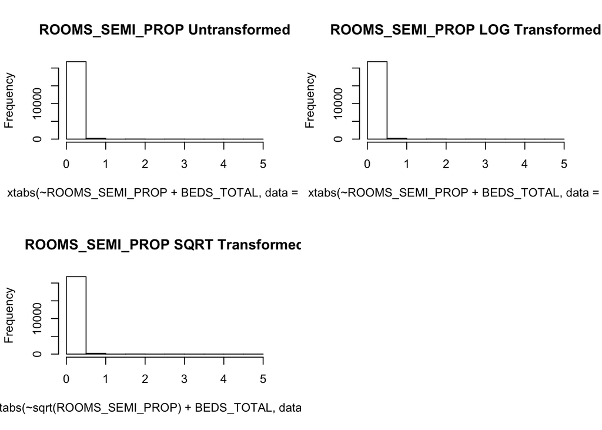

```r
# log transform
# infractions
df5 <- df4
df5$ROOMS_SEMI_PROP <- log(df4$ROOMS_SEMI_PROP)


par(mfrow=c(2,2))
hist(xtabs(~ROOMS_SEMI_PROP + BEDS_TOTAL, data=df4), main = "ROOMS_SEMI_PROP Untransformed")
hist(xtabs(~ROOMS_SEMI_PROP + BEDS_TOTAL, data=df5), main = "ROOMS_SEMI_PROP LOG Transformed")

# sqrt transform
hist(xtabs(~sqrt(ROOMS_SEMI_PROP) + BEDS_TOTAL, data=df4), main = "ROOMS_SEMI_PROP SQRT Transformed")



# log transform
# age under 65
df5 <- df4
df5$AGE_UNDER_65 <- log(df4$AGE_UNDER_65)


par(mfrow=c(2,2))
```

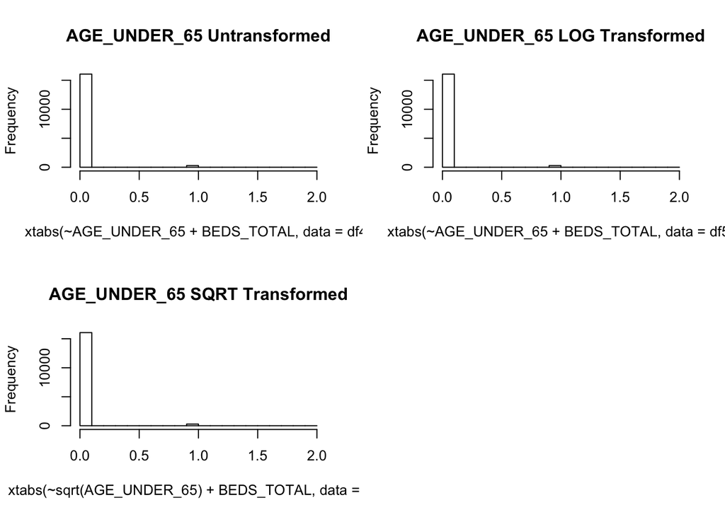

```r
hist(xtabs(~AGE_UNDER_65 + BEDS_TOTAL, data=df4), main = "AGE_UNDER_65 Untransformed")
hist(xtabs(~AGE_UNDER_65 + BEDS_TOTAL, data=df5), main = "AGE_UNDER_65 LOG Transformed")

# sqrt transform
hist(xtabs(~sqrt(AGE_UNDER_65) + BEDS_TOTAL, data=df4), main = "AGE_UNDER_65 SQRT Transformed")
```

Original, skewed data will be used for now.

#### Categorical Assessment

```r
# Inspect the distribution of the categorical variables

# hist(xtabs(~outbreak_status + FACILITY_NAME, data=df))
summary(df4$outbreak_status)
```

```
##  no yes
## 282  15
```

```r
# hist(xtabs(~residents_council + FACILITY_NAME, data=df))
summary(df4$residents_council)
```

```
##  no yes
##  32 265
```

```r
summary(df4$family_council)
```

```
##  no yes
##  46 251
```

```r
summary(df4$home_type)
```

```
##       for-profit health_authority       non-profit
##              102              112               83
```

**Remove: `ROOMS_TOTAL` and `ISE` to eliminate multicolinearity according to VIF output.**

```r
df4 <- df4[,-which(names(df4) %in% c('ROOMS_TOTAL', 'ISE'))]
# colnames(df4)
```

## Binary Logistic Regression with NAs

```r
fit2 = glm(outbreak_status~., family=binomial, data=df4, maxit = 25, na.action = na.pass)
summary(fit2)
```

`Error in glm.fit(x = c(1, 1, 1, 1, 1, 1, 1, 1, 1, 1, 1, 1, 1, 1, 1, 1, : NA/NaN/Inf in 'x'`

## Binary Logistic Regression without cols that have NAs

```r
no_nas <- colnames(df4)[colSums(is.na(df4)) == 0]
df_no_null <- df4[names(df4) %in% no_nas]
```

```r
fit3 = glm(outbreak_status~., family=binomial, data=df_no_null, maxit = 25)
summary(fit3)
```

```
##
## Call:
## glm(formula = outbreak_status ~ ., family = binomial, data = df_no_null,
##     maxit = 25)
##
## Deviance Residuals:
##     Min       1Q   Median       3Q      Max
## -1.1141  -0.3099  -0.2106  -0.1527   3.0905
##
## Coefficients:
##                            Estimate Std. Error z value Pr(>|z|)
## (Intercept)               -3.770301   2.445040  -1.542 0.123069
## BEDS_TOTAL                 0.017041   0.004497   3.789 0.000151 ***
## residents_councilyes       0.841179   1.170518   0.719 0.472364
## family_councilyes         -0.822898   0.760021  -1.083 0.278928
## accreditationunknown      -1.352867   0.904968  -1.495 0.134932
## accreditationyes          -1.322188   0.741405  -1.783 0.074529 .
## home_typehealth_authority  0.034378   0.800832   0.043 0.965759
## home_typenon-profit        0.154199   0.705467   0.219 0.826979
## BEDS_PUB_PROP             -0.342968   2.365675  -0.145 0.884729
## ---
## Signif. codes:  0 '***' 0.001 '**' 0.01 '*' 0.05 '.' 0.1 ' ' 1
##
## (Dispersion parameter for binomial family taken to be 1)
##
##     Null deviance: 118.80  on 296  degrees of freedom
## Residual deviance: 100.13  on 288  degrees of freedom
## AIC: 118.13
##
## Number of Fisher Scoring iterations: 7
```

## Binary Logistic Regression where NA ==> 0

Because each row represents an LTC, we do not want to omit any on the basis of NAs. Keeping NAs renders an error in LASSO so instead, 0s are imputed. ** Will this introduce bias? We dont know if LTCs that have NAs actually have high numbers or not.

```r
# impute 0 where NAs exist
df4[is.na(df4)] <- 0
```

```r
blr_fit <- glm(outbreak_status~., data = df4, family = binomial)
summary(blr_fit)
```

```
##
## Call:
## glm(formula = outbreak_status ~ ., family = binomial, data = df4)
##
## Deviance Residuals:
##      Min        1Q    Median        3Q       Max
## -1.49609  -0.19835  -0.08357  -0.02724   2.83843
##
## Coefficients:
##                             Estimate Std. Error z value Pr(>|z|)
## (Intercept)               -6.893e+00  7.841e+00  -0.879   0.3794
## BEDS_TOTAL                 2.008e-02  6.718e-03   2.989   0.0028 **
## SUB_COMPLAINTS             1.484e-01  3.151e-01   0.471   0.6377
## INCIDENT_FALL_100          7.271e-02  9.279e-02   0.784   0.4333
## INCIDENT_INJURY_100       -2.498e-01  3.569e-01  -0.700   0.4840
## FEMALE                     4.331e+00  5.399e+00   0.802   0.4225
## AGE_85_PLUS                6.152e-01  6.061e+00   0.102   0.9191
## AGE_UNDER_65              -1.395e+01  1.797e+01  -0.776   0.4377
## STAY_LENGTH                4.768e-04  9.730e-04   0.490   0.6241
## DEPRESSION                -1.187e+01  6.363e+00  -1.866   0.0621 .
## ADL_DEPENDENT              1.153e+01  5.975e+00   1.930   0.0536 .
## CPS_SEVERE                -1.016e+01  6.469e+00  -1.571   0.1162
## DEMENTIA                  -4.381e+00  4.407e+00  -0.994   0.3201
## ABS_PHYS_ABUSIVE           4.270e+00  1.150e+01   0.371   0.7103
## ISE_LOW                    1.383e-01  3.129e+00   0.044   0.9647
## CMI                       -5.315e+00  1.149e+01  -0.463   0.6435
## THERAPY_PT                -5.108e-01  3.627e+00  -0.141   0.8880
## THERAPY_RT                 2.636e+00  1.497e+00   1.761   0.0782 .
## THERAPY_OT                -8.423e+00  7.135e+00  -1.181   0.2378
## MEDS_DEPRESSION            1.033e+01  6.297e+00   1.640   0.1010
## MEDS_ANTIPSYCHOTICS        4.772e+00  5.181e+00   0.921   0.3570
## RESTRAINTS                -6.715e-01  7.303e+00  -0.092   0.9267
## INFRACTIONS               -3.624e-02  8.683e-02  -0.417   0.6764
## residents_councilyes       1.868e-01  1.743e+00   0.107   0.9147
## family_councilyes         -9.535e-01  1.222e+00  -0.780   0.4353
## accreditationunknown      -9.008e-01  1.361e+00  -0.662   0.5080
## accreditationyes          -1.192e+00  1.056e+00  -1.129   0.2589
## home_typehealth_authority -5.268e-01  1.499e+00  -0.351   0.7253
## home_typenon-profit       -1.004e+00  1.150e+00  -0.873   0.3827
## years_operating            5.976e-02  2.548e-02   2.346   0.0190 *
## BEDS_PUB_PROP              1.210e+00  3.923e+00   0.308   0.7578
## ROOMS_PRIV_PROP           -2.401e+00  2.039e+00  -1.178   0.2389
## ROOMS_SEMI_PROP           -1.080e+01  5.352e+00  -2.018   0.0436 *
## ---
## Signif. codes:  0 '***' 0.001 '**' 0.01 '*' 0.05 '.' 0.1 ' ' 1
##
## (Dispersion parameter for binomial family taken to be 1)
##
##     Null deviance: 118.800  on 296  degrees of freedom
## Residual deviance:  69.074  on 264  degrees of freedom
## AIC: 135.07
##
## Number of Fisher Scoring iterations: 9
```

## Binary Logistic Regression Assumptions

| assumption | check | result |
| --- | --- | --- |
| Linearity - linear relationship between continuous predictor variables and the logit of the outcome | visually - scatterplot | ok |
| Influential values | Cook’s distance plot of model fit | no obvious influential points |
| Multicolinearity | `car::vif(model)` | **ISSUE 1:** potentially perfect multicollinearity between `ownership_type` and `home_type`. **ISSUE 2:** Variable inflation factor for assessing multicollinearity - `BEDS_TOTAL`, `ROOMS_TOTAL`, `ISE`… |

```r
library(tidyverse)
library(broom)

mydata <- df4 %>%
  dplyr::select_if(is.numeric)
predictors <- colnames(mydata)

# Bind the logit and tidying the data for plot
probabilities <- predict(blr_fit, type = "response")
predicted.classes <- ifelse(probabilities > 0.5, "yes", "no")

mydata <- mydata %>%
  mutate(logit = log(probabilities/(1-probabilities))) %>%
  gather(key = "predictors", value = "predictor.value", -logit)


ggplot(mydata, aes(logit, predictor.value))+
  geom_point(size = 0.5, alpha = 0.5) +
  geom_smooth(method = "loess") +
  theme_bw() +
  facet_wrap(~predictors, scales = "free_y")
```

[output not shown]

```r
plot(blr_fit, which = 4, id.n = 3)
```

[output not shown]

```r
car::vif(blr_fit)
```

[output not shown]

```r
# Further assessing correlation
cor(df4$ISE, df4$ISE_LOW)

# cor(df4$ROOMS_TOTAL, df4$BEDS_TOTAL)
```

Warning in glm model implies potential separation of variables - for a particular value of a predictor, one outcome will always occur. **Determined `ownership_typepublic` caused perfect separation**

## LASSO with Imputed 0s

LASSO removes multi-colinear predictors.

```r
library(glmnet)
```

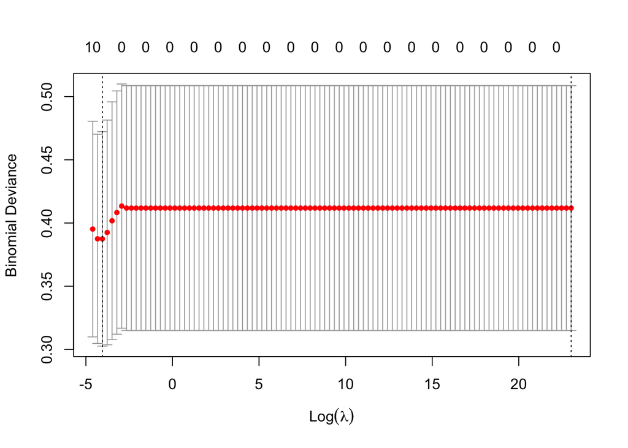

```r
# setup
# options(na.action="na.pass") #includes NA values

x <- model.matrix(outbreak_status~., data=df4)[,-42]
y <- df4$outbreak_status
grid=10^seq(10,-2,length=100)

fit_lasso = cv.glmnet(x,y, family="binomial", alpha = 1, lambda = grid, data=df4)
plot(fit_lasso)
```

Between 2-5 predictors are necessary.

```r
fit_lasso$lambda.min
```

```
## [1] 0.01747528
```

Lambda defines the amount of shrinkage required to minimize prediction error.

```r
coef(fit_lasso, fit_lasso$lambda.min)
```

```
## 34 x 1 sparse Matrix of class "dgCMatrix"
##                                     1
## (Intercept)               -4.17148253
## (Intercept)                .
## BEDS_TOTAL                 0.01026243
## SUB_COMPLAINTS             .
## INCIDENT_FALL_100          .
## INCIDENT_INJURY_100        .
## FEMALE                     .
## AGE_85_PLUS                .
## AGE_UNDER_65               .
## STAY_LENGTH                .
## DEPRESSION                 .
## ADL_DEPENDENT              .
## CPS_SEVERE                 .
## DEMENTIA                   .
## ABS_PHYS_ABUSIVE           .
## ISE_LOW                    .
## CMI                        .
## THERAPY_PT                 .
## THERAPY_RT                 0.26679192
## THERAPY_OT                 .
## MEDS_DEPRESSION            .
## MEDS_ANTIPSYCHOTICS        .
## RESTRAINTS                 .
## INFRACTIONS                .
## residents_councilyes       .
## family_councilyes          .
## accreditationunknown       .
## accreditationyes           .
## home_typehealth_authority  .
## home_typenon-profit        .
## years_operating            .
## BEDS_PUB_PROP              .
## ROOMS_PRIV_PROP            .
## ROOMS_SEMI_PROP            .
```

##### LASSO on non-null cols

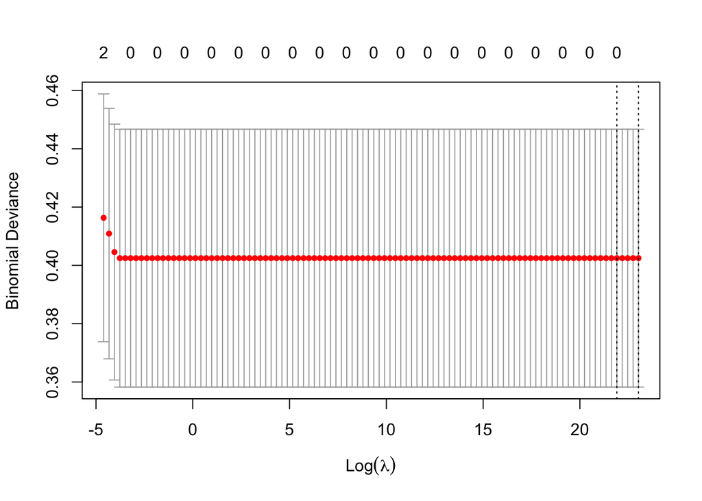

```r
x <- model.matrix(outbreak_status~., data=df_no_null)[,-2]
y <- df_no_null$outbreak_status
grid=10^seq(10,-2,length=100)

fit_lasso2 = cv.glmnet(x,y, family="binomial", alpha = 1, lambda = grid, data=df4)
plot(fit_lasso2)
```

0 predictors are necessary.

```r
fit_lasso2$lambda.min
```

```
## [1] 3274549163
```

Lambda defines the amount of shrinkage required to minimize prediction error.

```r
coef(fit_lasso2, fit_lasso2$lambda.min)
```

```
## 9 x 1 sparse Matrix of class "dgCMatrix"
##                                   1
## (Intercept)               -2.933857
## (Intercept)                .
## residents_councilyes       .
## family_councilyes          .
## accreditationunknown       .
## accreditationyes           .
## home_typehealth_authority  .
## home_typenon-profit        .
## BEDS_PUB_PROP              .
```

### Factor Analysis on Mixed Data

```r
library("FactoMineR")
library("factoextra")
```

```r
res <- FAMD(df4, graph = F)
eig.val <- get_eigenvalue(res)
head(eig.val)
```

```
##       eigenvalue variance.percent cumulative.variance.percent
## Dim.1   4.857369        14.719299                    14.71930
## Dim.2   2.961239         8.973450                    23.69275
## Dim.3   2.379033         7.209190                    30.90194
## Dim.4   1.857159         5.627754                    36.52969
## Dim.5   1.690963         5.124130                    41.65382
```

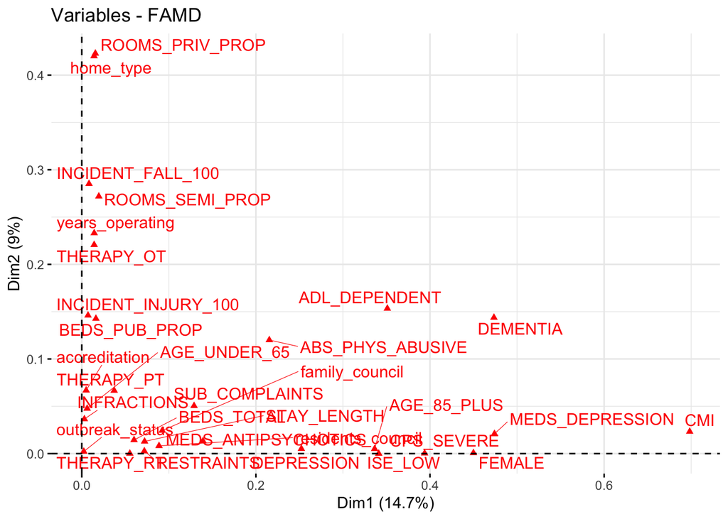

```r
fviz_famd_var(res, repel = TRUE)
```

quantitative variables

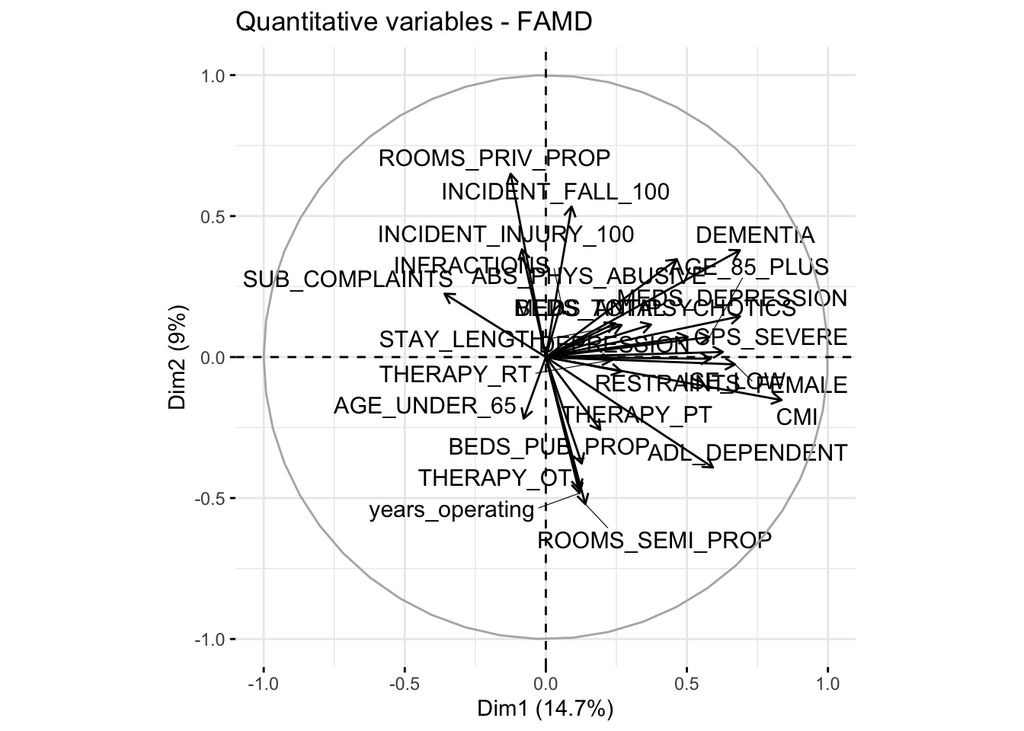

```r
fviz_famd_var(res, "quanti.var", repel = TRUE,
              col.var = "black", cex = 0.02)
```